# Get gene-region associations for a group of GO terms

Zuguang Gu

2024-02-05

Let’s first do a combination analysis with **rGREAT** and **simplifyEnrichment**. Let’s say, you have a list of genomic regions of interest (in the following example, we use a list of transcription factor binding sites). You do a GO enrichment analysis with **rGREAT** and visualize the enrichment results with **simplifyEnrichment**.

```r
library(rGREAT)
df = read.table(url("https://raw.githubusercontent.com/jokergoo/rGREAT_suppl/master/data/tb_encTfChipPkENCFF708LCH_A549_JUN_hg19.bed"))
# convert to a GRanges object
gr = GRanges(seqnames = df[, 1], ranges = IRanges(df[, 2], df[, 3]))
res = great(gr, "BP", "hg19")
tb = getEnrichmentTable(res)
head(tb)
```

```
##           id                         description genome_fraction observed_region_hits
## 1 GO:0097190         apoptotic signaling pathway      0.05142843                  175
## 2 GO:0042981     regulation of apoptotic process      0.13625922                  382
## 3 GO:0043067 regulation of programmed cell death      0.13923473                  385
## 4 GO:0010941            regulation of cell death      0.15491807                  413
## 5 GO:0006915                   apoptotic process      0.17416621                  458
## 6 GO:0033554         cellular response to stress      0.16660653                  438
##   fold_enrichment p_value p_adjust mean_tss_dist observed_gene_hits gene_set_size
## 1        1.971487       0        0        109284                109           585
## 2        1.624264       0        0        124438                270          1394
## 3        1.602036       0        0        125615                273          1426
## 4        1.544569       0        0        122812                295          1577
## 5        1.523564       0        0        122719                331          1833
## 6        1.523145       0        0        132952                307          1883
##   fold_enrichment_hyper p_value_hyper p_adjust_hyper
## 1              1.525021  3.675911e-06   7.282157e-05
## 2              1.585280  1.110223e-15   3.409079e-13
## 3              1.566925  3.552714e-15   8.311658e-13
## 4              1.531071  5.218048e-15   9.860104e-13
## 5              1.477987  1.387779e-14   2.351089e-12
## 6              1.334422  2.225650e-08   8.347036e-07
```

```r
library(simplifyEnrichment)
sig_go_ids = tb$id[tb$p_adjust < 0.001]
cl = simplifyGO(sig_go_ids)
```

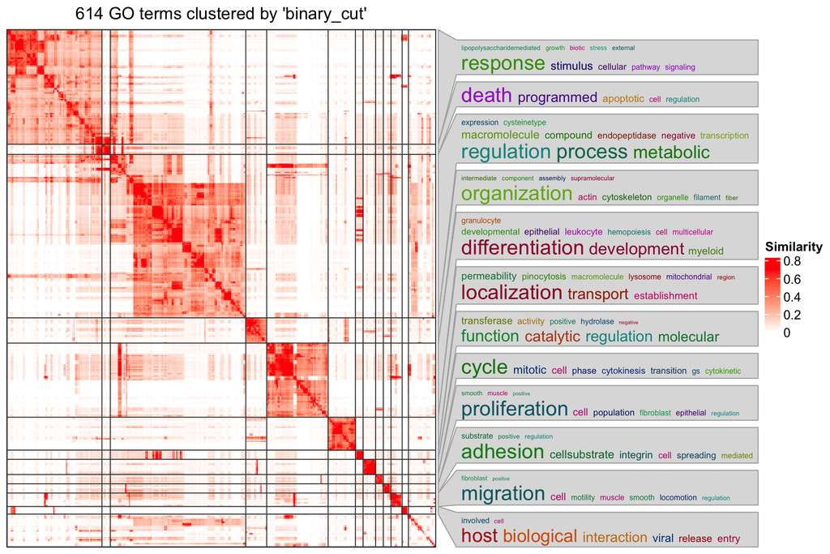

```r
head(cl)
```

```
##           id cluster
## 1 GO:0097190       1
## 2 GO:0042981       2
## 3 GO:0043067       2
## 4 GO:0010941       2
## 5 GO:0006915       2
## 6 GO:0033554       1
```

```r
table(cl$cluster)
```

```
##
##   1   2   3   4   5   6   7   8   9  10  11  12  13  14  15  16  17  18  19  20  21  22  23  24  25
## 136  12 194   1   1  30  88  39  11  18   5  11   5  11   1   1   1  16   9   1   4   3   5   2   1
##  26  27  28  29  30
##   1   3   1   2   1
```

The plot looks not bad. Next you may want to get the gene-region associations for significant GO terms. For example, the association for the first GO term:

```r
getRegionGeneAssociations(res, cl$id[1])
```

```
## GRanges object with 175 ranges and 2 metadata columns:
##         seqnames            ranges strand | annotated_genes    dist_to_TSS
##            <Rle>         <IRanges>  <Rle> | <CharacterList>  <IntegerList>
##     [1]     chr1 16472855-16473095      * |           EPHA2           9487
##     [2]     chr1 16490874-16491114      * |           EPHA2          -8292
##     [3]     chr1 23073949-23074189      * |           KDM1A        -271752
##     [4]     chr1 23912118-23912358      * |           RPL11        -105911
##     [5]     chr1 28479716-28479956      * |            EYA3         -64568
##     ...      ...               ...    ... .             ...            ...
##   [171]    chr20 48292419-48292659      * |           PTGIS        -107712
##   [172]    chr20 48782588-48782828      * |           CEBPB         -24292
##   [173]    chr20 48802827-48803067      * |           CEBPB          -4053
##   [174]    chr20 48989426-48989666      * |     CEBPB,PTPN1 182306,-137225
##   [175]    chr20 49039803-49040043      * |     CEBPB,PTPN1  232683,-86848
##   -------
##   seqinfo: 23 sequences from an unspecified genome; no seqlengths
```

There are more than 600 significant GO terms, and perhaps you don’t want to obtain such gene-region associations for every one of them.

As **simplifyEnrichment** already clusters significant GO terms into a smaller number of groups, you may switch your need of obtaining the associations from single GO terms to a group of GO terms where they show similar biological concept. In the new version of **rGREAT** (only available on GitHub currently), the second argument can be set as a vector of GO IDs. So, for example, to get the gene-region association for GO terms in the first cluster:

```r
getRegionGeneAssociations(res, cl$id[cl$cluster == 1])
```

```
## GRanges object with 1245 ranges and 2 metadata columns:
##          seqnames            ranges strand | annotated_genes    dist_to_TSS
##             <Rle>         <IRanges>  <Rle> | <CharacterList>  <IntegerList>
##      [1]     chr1   1280252-1280492      * |     TAS1R3,DVL1     13526,4000
##      [2]     chr1   2143913-2144153      * |          FAAP20          -4741
##      [3]     chr1   4052186-4052426      * |           AJAP1        -662679
##      [4]     chr1   4440698-4440938      * |           AJAP1        -274167
##      [5]     chr1   7359438-7359678      * |    CAMTA1,VAMP3 514054,-471651
##      ...      ...               ...    ... .             ...            ...
##   [1241]    chr22 37921455-37921695      * |          CARD10          -6077
##   [1242]    chr22 39096963-39097203      * |          GTPBP1          -4604
##   [1243]    chr22 39704855-39705095      * |      PDGFB,RPL3   -63898,11296
##   [1244]    chr22 40894508-40894748      * |     SGSM3,MRTFA  127913,137942
##   [1245]    chr22 50364455-50364695      * |    PIM3,IL17REL    10312,86360
##   -------
##   seqinfo: 23 sequences from an unspecified genome; no seqlengths
```